# Risk Factor Analysis

## Outcome Variable

**Outcome Variable:** haz

## Predictor Variables

**Intervention Variable:** birthlen

**Adjustment Set:**

- arm
- sex
- W_mage
- meducyrs
- feducyrs
- vagbrth
- single
- brthmon
- W_parity
- delta_W_mage
- delta_meducyrs
- delta_feducyrs
- delta_vagbrth
- delta_single
- delta_brthmon
- delta_W_parity

## Stratifying Variables

The analysis was stratified on these variable(s):

- agecat
- studyid
- country

## Data Summary

| agecat | studyid | country | birthlen | n_cell | n | outcome_variable |
| --- | --- | --- | --- | --- | --- | --- |
| Birth | CMC-V-BCS-2002 | INDIA | >=50 cm | 14 | 92 | haz |
| Birth | CMC-V-BCS-2002 | INDIA | <48 cm | 38 | 92 | haz |
| Birth | CMC-V-BCS-2002 | INDIA | [48-50) cm | 40 | 92 | haz |
| Birth | CMIN | BANGLADESH | >=50 cm | 2 | 26 | haz |
| Birth | CMIN | BANGLADESH | <48 cm | 19 | 26 | haz |
| Birth | CMIN | BANGLADESH | [48-50) cm | 5 | 26 | haz |
| Birth | COHORTS | GUATEMALA | >=50 cm | 437 | 852 | haz |
| Birth | COHORTS | GUATEMALA | <48 cm | 163 | 852 | haz |
| Birth | COHORTS | GUATEMALA | [48-50) cm | 252 | 852 | haz |
| Birth | COHORTS | INDIA | >=50 cm | 1426 | 6640 | haz |
| Birth | COHORTS | INDIA | <48 cm | 2774 | 6640 | haz |
| Birth | COHORTS | INDIA | [48-50) cm | 2440 | 6640 | haz |
| Birth | COHORTS | PHILIPPINES | >=50 cm | 1129 | 3050 | haz |
| Birth | COHORTS | PHILIPPINES | <48 cm | 762 | 3050 | haz |
| Birth | COHORTS | PHILIPPINES | [48-50) cm | 1159 | 3050 | haz |
| Birth | CONTENT | PERU | >=50 cm | 1 | 2 | haz |
| Birth | CONTENT | PERU | <48 cm | 1 | 2 | haz |
| Birth | CONTENT | PERU | [48-50) cm | 0 | 2 | haz |
| Birth | EE | PAKISTAN | >=50 cm | 22 | 240 | haz |
| Birth | EE | PAKISTAN | <48 cm | 172 | 240 | haz |
| Birth | EE | PAKISTAN | [48-50) cm | 46 | 240 | haz |
| Birth | GMS-Nepal | NEPAL | >=50 cm | 104 | 696 | haz |
| Birth | GMS-Nepal | NEPAL | <48 cm | 384 | 696 | haz |
| Birth | GMS-Nepal | NEPAL | [48-50) cm | 208 | 696 | haz |
| Birth | IRC | INDIA | >=50 cm | 142 | 388 | haz |
| Birth | IRC | INDIA | <48 cm | 108 | 388 | haz |
| Birth | IRC | INDIA | [48-50) cm | 138 | 388 | haz |
| Birth | JiVitA-3 | BANGLADESH | >=50 cm | 1228 | 22455 | haz |
| Birth | JiVitA-3 | BANGLADESH | <48 cm | 16136 | 22455 | haz |
| Birth | JiVitA-3 | BANGLADESH | [48-50) cm | 5091 | 22455 | haz |

[output cut: 198 more lines]

The following strata were considered:

- agecat: 24 months, studyid: CMC-V-BCS-2002, country: INDIA
- agecat: 24 months, studyid: CMIN, country: BANGLADESH
- agecat: 24 months, studyid: COHORTS, country: GUATEMALA
- agecat: 24 months, studyid: COHORTS, country: INDIA
- agecat: 24 months, studyid: COHORTS, country: PHILIPPINES
- agecat: 24 months, studyid: CONTENT, country: PERU
- agecat: 24 months, studyid: EE, country: PAKISTAN
- agecat: 24 months, studyid: GMS-Nepal, country: NEPAL
- agecat: 24 months, studyid: IRC, country: INDIA
- agecat: 24 months, studyid: JiVitA-3, country: BANGLADESH
- agecat: 24 months, studyid: JiVitA-4, country: BANGLADESH
- agecat: 24 months, studyid: Keneba, country: GAMBIA
- agecat: 24 months, studyid: MAL-ED, country: BANGLADESH
- agecat: 24 months, studyid: MAL-ED, country: BRAZIL
- agecat: 24 months, studyid: MAL-ED, country: INDIA
- agecat: 24 months, studyid: MAL-ED, country: NEPAL
- agecat: 24 months, studyid: MAL-ED, country: PERU
- agecat: 24 months, studyid: MAL-ED, country: SOUTH AFRICA
- agecat: 24 months, studyid: MAL-ED, country: TANZANIA, UNITED REPUBLIC OF
- agecat: 24 months, studyid: NIH-Birth, country: BANGLADESH
- agecat: 24 months, studyid: NIH-Crypto, country: BANGLADESH
- agecat: 24 months, studyid: PROBIT, country: BELARUS
- agecat: 24 months, studyid: PROVIDE, country: BANGLADESH
- agecat: 24 months, studyid: ZVITAMBO, country: ZIMBABWE
- agecat: 6 months, studyid: CMC-V-BCS-2002, country: INDIA
- agecat: 6 months, studyid: CMIN, country: BANGLADESH
- agecat: 6 months, studyid: COHORTS, country: GUATEMALA
- agecat: 6 months, studyid: COHORTS, country: INDIA
- agecat: 6 months, studyid: COHORTS, country: PHILIPPINES
- agecat: 6 months, studyid: CONTENT, country: PERU
- agecat: 6 months, studyid: EE, country: PAKISTAN
- agecat: 6 months, studyid: GMS-Nepal, country: NEPAL
- agecat: 6 months, studyid: IRC, country: INDIA
- agecat: 6 months, studyid: JiVitA-3, country: BANGLADESH
- agecat: 6 months, studyid: JiVitA-4, country: BANGLADESH
- agecat: 6 months, studyid: Keneba, country: GAMBIA
- agecat: 6 months, studyid: MAL-ED, country: BANGLADESH
- agecat: 6 months, studyid: MAL-ED, country: BRAZIL
- agecat: 6 months, studyid: MAL-ED, country: INDIA
- agecat: 6 months, studyid: MAL-ED, country: NEPAL
- agecat: 6 months, studyid: MAL-ED, country: PERU
- agecat: 6 months, studyid: MAL-ED, country: SOUTH AFRICA
- agecat: 6 months, studyid: MAL-ED, country: TANZANIA, UNITED REPUBLIC OF
- agecat: 6 months, studyid: NIH-Birth, country: BANGLADESH
- agecat: 6 months, studyid: NIH-Crypto, country: BANGLADESH
- agecat: 6 months, studyid: PROBIT, country: BELARUS
- agecat: 6 months, studyid: PROVIDE, country: BANGLADESH
- agecat: 6 months, studyid: ResPak, country: PAKISTAN
- agecat: 6 months, studyid: SAS-CompFeed, country: INDIA
- agecat: 6 months, studyid: ZVITAMBO, country: ZIMBABWE
- agecat: Birth, studyid: CMC-V-BCS-2002, country: INDIA
- agecat: Birth, studyid: CMIN, country: BANGLADESH
- agecat: Birth, studyid: COHORTS, country: GUATEMALA
- agecat: Birth, studyid: COHORTS, country: INDIA
- agecat: Birth, studyid: COHORTS, country: PHILIPPINES
- agecat: Birth, studyid: CONTENT, country: PERU
- agecat: Birth, studyid: EE, country: PAKISTAN
- agecat: Birth, studyid: GMS-Nepal, country: NEPAL
- agecat: Birth, studyid: IRC, country: INDIA
- agecat: Birth, studyid: JiVitA-3, country: BANGLADESH
- agecat: Birth, studyid: JiVitA-4, country: BANGLADESH
- agecat: Birth, studyid: Keneba, country: GAMBIA
- agecat: Birth, studyid: MAL-ED, country: BANGLADESH
- agecat: Birth, studyid: MAL-ED, country: BRAZIL
- agecat: Birth, studyid: MAL-ED, country: INDIA
- agecat: Birth, studyid: MAL-ED, country: NEPAL
- agecat: Birth, studyid: MAL-ED, country: PERU
- agecat: Birth, studyid: MAL-ED, country: SOUTH AFRICA
- agecat: Birth, studyid: MAL-ED, country: TANZANIA, UNITED REPUBLIC OF
- agecat: Birth, studyid: NIH-Birth, country: BANGLADESH
- agecat: Birth, studyid: NIH-Crypto, country: BANGLADESH
- agecat: Birth, studyid: PROBIT, country: BELARUS
- agecat: Birth, studyid: PROVIDE, country: BANGLADESH
- agecat: Birth, studyid: ResPak, country: PAKISTAN
- agecat: Birth, studyid: SAS-CompFeed, country: INDIA
- agecat: Birth, studyid: ZVITAMBO, country: ZIMBABWE

### Dropped Strata

Some strata were dropped due to rare outcomes:

- agecat: Birth, studyid: CMIN, country: BANGLADESH
- agecat: Birth, studyid: CONTENT, country: PERU
- agecat: 6 months, studyid: CMIN, country: BANGLADESH
- agecat: 6 months, studyid: CONTENT, country: PERU
- agecat: 24 months, studyid: CMIN, country: BANGLADESH
- agecat: 24 months, studyid: CONTENT, country: PERU

## Methods Detail

We’re interested in the causal parameters $E[Y_a]$ for all values of $a \in \mathcal{A}$. These parameters represent the mean outcome if, possibly contrary to fact, we intervened to set all units to have $A=a$. Under the randomization and positivity assumptions, these are identified by the statistical parameters $\psi_a=E_W[E_{Y|A,W}(Y|A=a,W)]$. In addition, we’re interested in the mean of $Y$, $E[Y]$ under no intervention (the observed mean). We will estimate these parameters by using SuperLearner to fit the relevant likelihood factors – $E_{Y|A,W}(Y|A=a,W)$ and $p(A=a|W)$, and then updating our likelihood fit using a joint TMLE.

For unadjusted analyses ($W=\{\}$), initial likelihoods were estimated using Lrnr_glm to estimate the simple $E(Y|A)$ and Lrnr_mean to estimate $p(A)$. For adjusted analyses, a small library containing Lrnr_glmnet, Lrnr_xgboost, and Lrnr_mean was used.

Having estimated these parameters, we will then use the delta method to estimate relative risks and attributable risks relative to a prespecified baseline level of $A$.

# Results Detail

## Results Plots

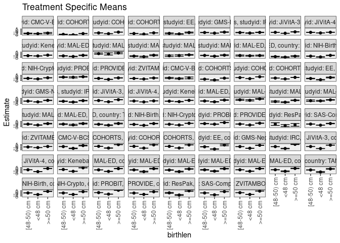

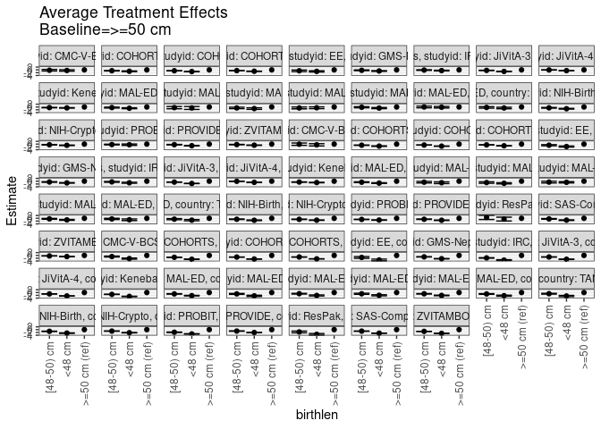

[figure not shown]

## Results Table

### Parameter: TSM

| agecat | studyid | country | intervention_level | baseline_level | estimate | ci_lower | ci_upper |
| --- | --- | --- | --- | --- | --- | --- | --- |
| Birth | CMC-V-BCS-2002 | INDIA | >=50 cm | NA | 0.3130172 | -0.0030557 | 0.6290902 |
| Birth | CMC-V-BCS-2002 | INDIA | <48 cm | NA | -1.9441387 | -2.1919275 | -1.6963499 |
| Birth | CMC-V-BCS-2002 | INDIA | [48-50) cm | NA | -0.5055830 | -0.6039149 | -0.4072511 |
| Birth | COHORTS | GUATEMALA | >=50 cm | NA | 1.0545755 | 0.9901961 | 1.1189550 |
| Birth | COHORTS | GUATEMALA | <48 cm | NA | -1.6870770 | -1.8229346 | -1.5512194 |
| Birth | COHORTS | GUATEMALA | [48-50) cm | NA | -0.2905062 | -0.3347339 | -0.2462784 |
| Birth | COHORTS | INDIA | >=50 cm | NA | 0.8367096 | 0.8010539 | 0.8723653 |
| Birth | COHORTS | INDIA | <48 cm | NA | -1.7319030 | -1.7612679 | -1.7025380 |
| Birth | COHORTS | INDIA | [48-50) cm | NA | -0.3381335 | -0.3522415 | -0.3240255 |
| Birth | COHORTS | PHILIPPINES | >=50 cm | NA | 0.7906621 | 0.7562293 | 0.8250949 |
| Birth | COHORTS | PHILIPPINES | <48 cm | NA | -1.6563050 | -1.7109980 | -1.6016121 |
| Birth | COHORTS | PHILIPPINES | [48-50) cm | NA | -0.3389635 | -0.3587738 | -0.3191532 |
| Birth | EE | PAKISTAN | >=50 cm | NA | 0.7670766 | 0.1721280 | 1.3620253 |
| Birth | EE | PAKISTAN | <48 cm | NA | -2.4837084 | -2.6504809 | -2.3169360 |
| Birth | EE | PAKISTAN | [48-50) cm | NA | -0.6862822 | -0.8012421 | -0.5713223 |
| Birth | GMS-Nepal | NEPAL | >=50 cm | NA | 0.5302780 | 0.4395304 | 0.6210257 |
| Birth | GMS-Nepal | NEPAL | <48 cm | NA | -1.8337458 | -1.9071988 | -1.7602928 |
| Birth | GMS-Nepal | NEPAL | [48-50) cm | NA | -0.5147321 | -0.5644822 | -0.4649819 |
| Birth | IRC | INDIA | >=50 cm | NA | 1.2661411 | 1.0854664 | 1.4468158 |
| Birth | IRC | INDIA | <48 cm | NA | -2.0649724 | -2.2725084 | -1.8574364 |
| Birth | IRC | INDIA | [48-50) cm | NA | -0.5341743 | -0.5917386 | -0.4766099 |
| Birth | JiVitA-3 | BANGLADESH | >=50 cm | NA | 0.6401494 | 0.5951843 | 0.6851145 |
| Birth | JiVitA-3 | BANGLADESH | <48 cm | NA | -2.0908372 | -2.1071451 | -2.0745293 |
| Birth | JiVitA-3 | BANGLADESH | [48-50) cm | NA | -0.4766331 | -0.4879184 | -0.4653478 |
| Birth | JiVitA-4 | BANGLADESH | >=50 cm | NA | 0.4036720 | 0.3117569 | 0.4955871 |
| Birth | JiVitA-4 | BANGLADESH | <48 cm | NA | -2.0553169 | -2.0972172 | -2.0134166 |
| Birth | JiVitA-4 | BANGLADESH | [48-50) cm | NA | -0.5868697 | -0.6186238 | -0.5551156 |
| Birth | Keneba | GAMBIA | >=50 cm | NA | 0.9726336 | 0.9177015 | 1.0275657 |
| Birth | Keneba | GAMBIA | <48 cm | NA | -1.8079822 | -1.9278626 | -1.6881018 |
| Birth | Keneba | GAMBIA | [48-50) cm | NA | -0.3583700 | -0.3898943 | -0.3268456 |

[output cut: 180 more lines]

### Parameter: E(Y)

| agecat | studyid | country | intervention_level | baseline_level | estimate | ci_lower | ci_upper |
| --- | --- | --- | --- | --- | --- | --- | --- |
| Birth | CMC-V-BCS-2002 | INDIA | NA | NA | -0.9611957 | -1.1776967 | -0.7446946 |
| Birth | COHORTS | GUATEMALA | NA | NA | 0.1297300 | 0.0458017 | 0.2136584 |
| Birth | COHORTS | INDIA | NA | NA | -0.6698961 | -0.6980556 | -0.6417365 |
| Birth | COHORTS | PHILIPPINES | NA | NA | -0.2490492 | -0.2880580 | -0.2100404 |
| Birth | EE | PAKISTAN | NA | NA | -1.8608750 | -2.0482045 | -1.6735455 |
| Birth | GMS-Nepal | NEPAL | NA | NA | -1.0851580 | -1.1651811 | -1.0051350 |
| Birth | IRC | INDIA | NA | NA | -0.3080412 | -0.4687931 | -0.1472894 |
| Birth | JiVitA-3 | BANGLADESH | NA | NA | -1.5894148 | -1.6086362 | -1.5701935 |
| Birth | JiVitA-4 | BANGLADESH | NA | NA | -1.5232908 | -1.5723277 | -1.4742539 |
| Birth | Keneba | GAMBIA | NA | NA | 0.0308036 | -0.0328378 | 0.0944451 |
| Birth | MAL-ED | BANGLADESH | NA | NA | -1.1180952 | -1.2525408 | -0.9836496 |
| Birth | MAL-ED | BRAZIL | NA | NA | -0.6760000 | -0.9521457 | -0.3998543 |
| Birth | MAL-ED | INDIA | NA | NA | -1.2036170 | -1.4976814 | -0.9095527 |
| Birth | MAL-ED | NEPAL | NA | NA | -0.8533333 | -1.2104864 | -0.4961803 |
| Birth | MAL-ED | PERU | NA | NA | -0.8827897 | -1.0001058 | -0.7654736 |
| Birth | MAL-ED | SOUTH AFRICA | NA | NA | -0.6317073 | -0.8249555 | -0.4384591 |
| Birth | MAL-ED | TANZANIA, UNITED REPUBLIC OF | NA | NA | -1.1556000 | -1.3655361 | -0.9456639 |
| Birth | NIH-Birth | BANGLADESH | NA | NA | -0.9310197 | -1.0197391 | -0.8423003 |
| Birth | NIH-Crypto | BANGLADESH | NA | NA | -0.9094945 | -0.9809370 | -0.8380521 |
| Birth | PROBIT | BELARUS | NA | NA | 1.3114417 | 1.1524752 | 1.4704082 |
| Birth | PROVIDE | BANGLADESH | NA | NA | -0.8851020 | -0.9601332 | -0.8100709 |
| Birth | ResPak | PAKISTAN | NA | NA | -0.9800000 | -1.4086438 | -0.5513562 |
| Birth | SAS-CompFeed | INDIA | NA | NA | -1.4314217 | -1.5099245 | -1.3529189 |
| Birth | ZVITAMBO | ZIMBABWE | NA | NA | -0.5002724 | -0.5208163 | -0.4797285 |
| 6 months | CMC-V-BCS-2002 | INDIA | NA | NA | -1.2953686 | -1.5534398 | -1.0372973 |
| 6 months | COHORTS | GUATEMALA | NA | NA | -1.7553052 | -1.8330182 | -1.6775923 |
| 6 months | COHORTS | INDIA | NA | NA | -0.9973610 | -1.0266429 | -0.9680792 |
| 6 months | COHORTS | PHILIPPINES | NA | NA | -1.1429137 | -1.1848624 | -1.1009651 |
| 6 months | EE | PAKISTAN | NA | NA | -2.1264619 | -2.2795142 | -1.9734095 |
| 6 months | GMS-Nepal | NEPAL | NA | NA | -1.3510539 | -1.4294158 | -1.2726919 |
| 6 months | IRC | INDIA | NA | NA | -1.2263582 | -1.3620220 | -1.0906944 |
| 6 months | JiVitA-3 | BANGLADESH | NA | NA | -1.3303469 | -1.3544501 | -1.3062437 |
| 6 months | JiVitA-4 | BANGLADESH | NA | NA | -1.3464316 | -1.3887462 | -1.3041170 |
| 6 months | Keneba | GAMBIA | NA | NA | -0.9034101 | -0.9602836 | -0.8465366 |
| 6 months | MAL-ED | BANGLADESH | NA | NA | -1.2087678 | -1.3332048 | -1.0843307 |
| 6 months | MAL-ED | BRAZIL | NA | NA | 0.0564689 | -0.1983718 | 0.3113097 |
| 6 months | MAL-ED | INDIA | NA | NA | -1.5092276 | -1.7906712 | -1.2277841 |
| 6 months | MAL-ED | NEPAL | NA | NA | -0.6684615 | -0.9484552 | -0.3884679 |
| 6 months | MAL-ED | PERU | NA | NA | -1.2930271 | -1.4141974 | -1.1718569 |
| 6 months | MAL-ED | SOUTH AFRICA | NA | NA | -1.0985125 | -1.3092915 | -0.8877336 |
| 6 months | MAL-ED | TANZANIA, UNITED REPUBLIC OF | NA | NA | -1.3305226 | -1.5032169 | -1.1578283 |
| 6 months | NIH-Birth | BANGLADESH | NA | NA | -1.4092745 | -1.5003907 | -1.3181582 |
| 6 months | NIH-Crypto | BANGLADESH | NA | NA | -1.1986783 | -1.2700937 | -1.1272630 |
| 6 months | PROBIT | BELARUS | NA | NA | 0.0980074 | 0.0062724 | 0.1897424 |
| 6 months | PROVIDE | BANGLADESH | NA | NA | -1.0916915 | -1.1661176 | -1.0172654 |
| 6 months | ResPak | PAKISTAN | NA | NA | -1.7077451 | -2.2839081 | -1.1315821 |
| 6 months | SAS-CompFeed | INDIA | NA | NA | -1.4030363 | -1.4821426 | -1.3239299 |
| 6 months | ZVITAMBO | ZIMBABWE | NA | NA | -0.8671231 | -0.8928063 | -0.8414399 |
| 24 months | CMC-V-BCS-2002 | INDIA | NA | NA | -2.4800629 | -2.6380751 | -2.3220507 |
| 24 months | COHORTS | GUATEMALA | NA | NA | -2.9426964 | -3.0309681 | -2.8544248 |
| 24 months | COHORTS | INDIA | NA | NA | -2.1193232 | -2.1537519 | -2.0848946 |
| 24 months | COHORTS | PHILIPPINES | NA | NA | -2.4157330 | -2.4606528 | -2.3708132 |
| 24 months | EE | PAKISTAN | NA | NA | -2.6323899 | -2.8110257 | -2.4537542 |
| 24 months | GMS-Nepal | NEPAL | NA | NA | -1.8864887 | -1.9720856 | -1.8008918 |
| 24 months | IRC | INDIA | NA | NA | -1.7882863 | -1.8843577 | -1.6922149 |
| 24 months | JiVitA-3 | BANGLADESH | NA | NA | -2.0375014 | -2.0671576 | -2.0078452 |
| 24 months | JiVitA-4 | BANGLADESH | NA | NA | -1.7719162 | -1.8104910 | -1.7333415 |
| 24 months | Keneba | GAMBIA | NA | NA | -1.5564333 | -1.6186769 | -1.4941898 |
| 24 months | MAL-ED | BANGLADESH | NA | NA | -2.0004545 | -2.1320336 | -1.8688755 |
| 24 months | MAL-ED | BRAZIL | NA | NA | -0.0901587 | -0.4299024 | 0.2495849 |
| 24 months | MAL-ED | INDIA | NA | NA | -2.1964103 | -2.4711826 | -1.9216379 |
| 24 months | MAL-ED | NEPAL | NA | NA | -1.5280769 | -1.8563546 | -1.1997992 |
| 24 months | MAL-ED | PERU | NA | NA | -1.7565208 | -1.8888943 | -1.6241474 |
| 24 months | MAL-ED | SOUTH AFRICA | NA | NA | -1.5850366 | -1.8154417 | -1.3546316 |
| 24 months | MAL-ED | TANZANIA, UNITED REPUBLIC OF | NA | NA | -2.5537500 | -2.7412414 | -2.3662586 |
| 24 months | NIH-Birth | BANGLADESH | NA | NA | -2.2268619 | -2.3322626 | -2.1214612 |
| 24 months | NIH-Crypto | BANGLADESH | NA | NA | -1.4412646 | -1.5249156 | -1.3576135 |
| 24 months | PROBIT | BELARUS | NA | NA | -0.1442891 | -0.4253755 | 0.1367972 |
| 24 months | PROVIDE | BANGLADESH | NA | NA | -1.6024221 | -1.6857420 | -1.5191023 |
| 24 months | ZVITAMBO | ZIMBABWE | NA | NA | -1.6032245 | -1.6608525 | -1.5455965 |

### Parameter: ATE

| agecat | studyid | country | intervention_level | baseline_level | estimate | ci_lower | ci_upper |
| --- | --- | --- | --- | --- | --- | --- | --- |
| Birth | CMC-V-BCS-2002 | INDIA | >=50 cm | >=50 cm | 0.0000000 | 0.0000000 | 0.0000000 |
| Birth | CMC-V-BCS-2002 | INDIA | <48 cm | >=50 cm | -2.2571559 | -2.6593304 | -1.8549815 |
| Birth | CMC-V-BCS-2002 | INDIA | [48-50) cm | >=50 cm | -0.8186003 | -1.1499222 | -0.4872783 |
| Birth | COHORTS | GUATEMALA | >=50 cm | >=50 cm | 0.0000000 | 0.0000000 | 0.0000000 |
| Birth | COHORTS | GUATEMALA | <48 cm | >=50 cm | -2.7416525 | -2.8931552 | -2.5901498 |
| Birth | COHORTS | GUATEMALA | [48-50) cm | >=50 cm | -1.3450817 | -1.4227143 | -1.2674491 |
| Birth | COHORTS | INDIA | >=50 cm | >=50 cm | 0.0000000 | 0.0000000 | 0.0000000 |
| Birth | COHORTS | INDIA | <48 cm | >=50 cm | -2.5686126 | -2.6146957 | -2.5225295 |
| Birth | COHORTS | INDIA | [48-50) cm | >=50 cm | -1.1748431 | -1.2128782 | -1.1368080 |
| Birth | COHORTS | PHILIPPINES | >=50 cm | >=50 cm | 0.0000000 | 0.0000000 | 0.0000000 |
| Birth | COHORTS | PHILIPPINES | <48 cm | >=50 cm | -2.4469671 | -2.5114366 | -2.3824976 |
| Birth | COHORTS | PHILIPPINES | [48-50) cm | >=50 cm | -1.1296256 | -1.1691132 | -1.0901380 |
| Birth | EE | PAKISTAN | >=50 cm | >=50 cm | 0.0000000 | 0.0000000 | 0.0000000 |
| Birth | EE | PAKISTAN | <48 cm | >=50 cm | -3.2507851 | -3.8694582 | -2.6321120 |
| Birth | EE | PAKISTAN | [48-50) cm | >=50 cm | -1.4533588 | -2.0599789 | -0.8467388 |
| Birth | GMS-Nepal | NEPAL | >=50 cm | >=50 cm | 0.0000000 | 0.0000000 | 0.0000000 |
| Birth | GMS-Nepal | NEPAL | <48 cm | >=50 cm | -2.3640239 | -2.4808060 | -2.2472417 |
| Birth | GMS-Nepal | NEPAL | [48-50) cm | >=50 cm | -1.0450101 | -1.1479146 | -0.9421056 |
| Birth | IRC | INDIA | >=50 cm | >=50 cm | 0.0000000 | 0.0000000 | 0.0000000 |
| Birth | IRC | INDIA | <48 cm | >=50 cm | -3.3311135 | -3.6064834 | -3.0557436 |
| Birth | IRC | INDIA | [48-50) cm | >=50 cm | -1.8003154 | -1.9901757 | -1.6104550 |
| Birth | JiVitA-3 | BANGLADESH | >=50 cm | >=50 cm | 0.0000000 | 0.0000000 | 0.0000000 |
| Birth | JiVitA-3 | BANGLADESH | <48 cm | >=50 cm | -2.7309866 | -2.7798501 | -2.6821230 |
| Birth | JiVitA-3 | BANGLADESH | [48-50) cm | >=50 cm | -1.1167824 | -1.1626633 | -1.0709016 |
| Birth | JiVitA-4 | BANGLADESH | >=50 cm | >=50 cm | 0.0000000 | 0.0000000 | 0.0000000 |
| Birth | JiVitA-4 | BANGLADESH | <48 cm | >=50 cm | -2.4589889 | -2.5603150 | -2.3576629 |
| Birth | JiVitA-4 | BANGLADESH | [48-50) cm | >=50 cm | -0.9905417 | -1.0893959 | -0.8916876 |
| Birth | Keneba | GAMBIA | >=50 cm | >=50 cm | 0.0000000 | 0.0000000 | 0.0000000 |
| Birth | Keneba | GAMBIA | <48 cm | >=50 cm | -2.7806158 | -2.9128256 | -2.6484060 |
| Birth | Keneba | GAMBIA | [48-50) cm | >=50 cm | -1.3310036 | -1.3939808 | -1.2680263 |

[output cut: 180 more lines]

### Parameter: PAR

| agecat | studyid | country | intervention_level | baseline_level | estimate | ci_lower | ci_upper |
| --- | --- | --- | --- | --- | --- | --- | --- |
| Birth | CMC-V-BCS-2002 | INDIA | >=50 cm | NA | -1.2742129 | -1.6158789 | -0.9325468 |
| Birth | COHORTS | GUATEMALA | >=50 cm | NA | -0.9248455 | -1.0098736 | -0.8398174 |
| Birth | COHORTS | INDIA | >=50 cm | NA | -1.5066057 | -1.5467037 | -1.4665077 |
| Birth | COHORTS | PHILIPPINES | >=50 cm | NA | -1.0397113 | -1.0825742 | -0.9968483 |
| Birth | EE | PAKISTAN | >=50 cm | NA | -2.6279516 | -3.2098302 | -2.0460730 |
| Birth | GMS-Nepal | NEPAL | >=50 cm | NA | -1.6154361 | -1.7268699 | -1.5040023 |
| Birth | IRC | INDIA | >=50 cm | NA | -1.5741823 | -1.7605788 | -1.3877859 |
| Birth | JiVitA-3 | BANGLADESH | >=50 cm | NA | -2.2295642 | -2.2792189 | -2.1799095 |
| Birth | JiVitA-4 | BANGLADESH | >=50 cm | NA | -1.9269628 | -2.0252133 | -1.8287124 |
| Birth | Keneba | GAMBIA | >=50 cm | NA | -0.9418300 | -1.0066294 | -0.8770306 |
| Birth | MAL-ED | BANGLADESH | >=50 cm | NA | -1.4576535 | -1.6360125 | -1.2792946 |
| Birth | MAL-ED | BRAZIL | >=50 cm | NA | -0.9910922 | -1.3048020 | -0.6773824 |
| Birth | MAL-ED | INDIA | >=50 cm | NA | -1.2702837 | -1.6001173 | -0.9404501 |
| Birth | MAL-ED | NEPAL | >=50 cm | NA | -1.1476190 | -1.5400980 | -0.7551401 |
| Birth | MAL-ED | PERU | >=50 cm | NA | -1.2110052 | -1.4039267 | -1.0180837 |
| Birth | MAL-ED | SOUTH AFRICA | >=50 cm | NA | -1.0953505 | -1.3309672 | -0.8597338 |
| Birth | MAL-ED | TANZANIA, UNITED REPUBLIC OF | >=50 cm | NA | -1.2941272 | -1.6030330 | -0.9852214 |
| Birth | NIH-Birth | BANGLADESH | >=50 cm | NA | -1.4973489 | -1.6284693 | -1.3662286 |
| Birth | NIH-Crypto | BANGLADESH | >=50 cm | NA | -1.2767136 | -1.3716805 | -1.1817467 |
| Birth | PROBIT | BELARUS | >=50 cm | NA | -0.1826258 | -0.2219539 | -0.1432977 |
| Birth | PROVIDE | BANGLADESH | >=50 cm | NA | -1.1799985 | -1.2838944 | -1.0761026 |
| Birth | ResPak | PAKISTAN | >=50 cm | NA | -2.0519963 | -2.6768223 | -1.4271702 |
| Birth | SAS-CompFeed | INDIA | >=50 cm | NA | -1.8444481 | -1.9376852 | -1.7512110 |
| Birth | ZVITAMBO | ZIMBABWE | >=50 cm | NA | -1.3362015 | -1.3623358 | -1.3100672 |
| 6 months | CMC-V-BCS-2002 | INDIA | >=50 cm | NA | -0.2760680 | -0.9354045 | 0.3832685 |
| 6 months | COHORTS | GUATEMALA | >=50 cm | NA | -0.5149073 | -0.5920218 | -0.4377928 |
| 6 months | COHORTS | INDIA | >=50 cm | NA | -0.8525843 | -0.9032823 | -0.8018863 |
| 6 months | COHORTS | PHILIPPINES | >=50 cm | NA | -0.5175701 | -0.5706153 | -0.4645249 |
| 6 months | EE | PAKISTAN | >=50 cm | NA | -1.4117424 | -1.7416819 | -1.0818029 |
| 6 months | GMS-Nepal | NEPAL | >=50 cm | NA | -0.8266230 | -0.9948675 | -0.6583785 |
| 6 months | IRC | INDIA | >=50 cm | NA | -0.4820985 | -0.6562863 | -0.3079108 |
| 6 months | JiVitA-3 | BANGLADESH | >=50 cm | NA | -1.3173462 | -1.3863992 | -1.2482931 |
| 6 months | JiVitA-4 | BANGLADESH | >=50 cm | NA | -0.4054032 | -0.4689969 | -0.3418095 |
| 6 months | Keneba | GAMBIA | >=50 cm | NA | -0.3627686 | -0.4208213 | -0.3047159 |
| 6 months | MAL-ED | BANGLADESH | >=50 cm | NA | -0.9190935 | -1.1381467 | -0.7000402 |
| 6 months | MAL-ED | BRAZIL | >=50 cm | NA | -0.5723846 | -0.8960600 | -0.2487091 |
| 6 months | MAL-ED | INDIA | >=50 cm | NA | -1.0433943 | -1.3884372 | -0.6983515 |
| 6 months | MAL-ED | NEPAL | >=50 cm | NA | -0.5334615 | -0.8581966 | -0.2087265 |
| 6 months | MAL-ED | PERU | >=50 cm | NA | -0.6561602 | -0.9092410 | -0.4030793 |
| 6 months | MAL-ED | SOUTH AFRICA | >=50 cm | NA | -0.4981091 | -0.8004413 | -0.1957769 |
| 6 months | MAL-ED | TANZANIA, UNITED REPUBLIC OF | >=50 cm | NA | -0.7709964 | -1.0973409 | -0.4446518 |
| 6 months | NIH-Birth | BANGLADESH | >=50 cm | NA | -0.8181347 | -0.9914655 | -0.6448039 |
| 6 months | NIH-Crypto | BANGLADESH | >=50 cm | NA | -0.7904659 | -0.8975383 | -0.6833935 |
| 6 months | PROBIT | BELARUS | >=50 cm | NA | -0.0790436 | -0.0956406 | -0.0624466 |
| 6 months | PROVIDE | BANGLADESH | >=50 cm | NA | -0.7762952 | -0.8991965 | -0.6533938 |
| 6 months | ResPak | PAKISTAN | >=50 cm | NA | -0.0683701 | -1.0501699 | 0.9134297 |
| 6 months | SAS-CompFeed | INDIA | >=50 cm | NA | -0.8378933 | -1.0320430 | -0.6437437 |
| 6 months | ZVITAMBO | ZIMBABWE | >=50 cm | NA | -0.4110006 | -0.4491302 | -0.3728710 |
| 24 months | CMC-V-BCS-2002 | INDIA | >=50 cm | NA | -0.3071057 | -0.7437521 | 0.1295407 |
| 24 months | COHORTS | GUATEMALA | >=50 cm | NA | -0.4052108 | -0.4980284 | -0.3123933 |
| 24 months | COHORTS | INDIA | >=50 cm | NA | -0.7266816 | -0.7890953 | -0.6642678 |
| 24 months | COHORTS | PHILIPPINES | >=50 cm | NA | -0.4514620 | -0.5094169 | -0.3935071 |
| 24 months | EE | PAKISTAN | >=50 cm | NA | -0.9051556 | -1.2876820 | -0.5226292 |
| 24 months | GMS-Nepal | NEPAL | >=50 cm | NA | -0.5028226 | -0.7043580 | -0.3012872 |
| 24 months | IRC | INDIA | >=50 cm | NA | -0.1937891 | -0.3246619 | -0.0629164 |
| 24 months | JiVitA-3 | BANGLADESH | >=50 cm | NA | -0.8729911 | -0.9755744 | -0.7704078 |
| 24 months | JiVitA-4 | BANGLADESH | >=50 cm | NA | -0.2810052 | -0.3405747 | -0.2214358 |
| 24 months | Keneba | GAMBIA | >=50 cm | NA | -0.2671405 | -0.3287751 | -0.2055059 |
| 24 months | MAL-ED | BANGLADESH | >=50 cm | NA | -0.5422960 | -0.7951497 | -0.2894424 |
| 24 months | MAL-ED | BRAZIL | >=50 cm | NA | -0.4575827 | -0.9317708 | 0.0166053 |
| 24 months | MAL-ED | INDIA | >=50 cm | NA | -0.8139103 | -1.2350164 | -0.3928041 |
| 24 months | MAL-ED | NEPAL | >=50 cm | NA | -0.4473626 | -0.8281695 | -0.0665558 |
| 24 months | MAL-ED | PERU | >=50 cm | NA | -0.4156302 | -0.7310199 | -0.1002404 |
| 24 months | MAL-ED | SOUTH AFRICA | >=50 cm | NA | 0.0271199 | -0.3301191 | 0.3843590 |
| 24 months | MAL-ED | TANZANIA, UNITED REPUBLIC OF | >=50 cm | NA | -0.4001403 | -0.8207563 | 0.0204757 |
| 24 months | NIH-Birth | BANGLADESH | >=50 cm | NA | -0.7396510 | -0.9278473 | -0.5514547 |
| 24 months | NIH-Crypto | BANGLADESH | >=50 cm | NA | -0.5029446 | -0.6244802 | -0.3814090 |
| 24 months | PROBIT | BELARUS | >=50 cm | NA | -0.0285123 | -0.0537343 | -0.0032903 |
| 24 months | PROVIDE | BANGLADESH | >=50 cm | NA | -0.5683822 | -0.7002569 | -0.4365075 |
| 24 months | ZVITAMBO | ZIMBABWE | >=50 cm | NA | -0.4855737 | -0.5986075 | -0.3725400 |